# Untitled

## 5.1 Descrição univariada

Nesta sessão vamos ver alguns (mas não todos!) comandos do R para fazer uma análise descritiva de um conjunto de dados.

Uma boa forma de iniciar uma análise descritiva adequada é verificar os tipoa de variáveis disponíveis. Variáveis podem ser classificadas da seguinte forma:

- qualitativas (categóricas)
- nominais
- ordinais
- quantitativas
- discretas
- contínuas
- e podem ser resumidas por tabelas, gráficos e/ou medidas.

Vamos ilustrar estes conceitos com um conjunto de dados já incluído no R, o conjunto mtcars que descreve características de diferentes modelos de automóvel.

```r
data(mtcars)
mtcars         # mostra todo o conjunto de dados
```

```
##                      mpg cyl  disp  hp drat    wt  qsec vs am gear carb
## Mazda RX4           21.0   6 160.0 110 3.90 2.620 16.46  0  1    4    4
## Mazda RX4 Wag       21.0   6 160.0 110 3.90 2.875 17.02  0  1    4    4
## Datsun 710          22.8   4 108.0  93 3.85 2.320 18.61  1  1    4    1
## Hornet 4 Drive      21.4   6 258.0 110 3.08 3.215 19.44  1  0    3    1
## Hornet Sportabout   18.7   8 360.0 175 3.15 3.440 17.02  0  0    3    2
## Valiant             18.1   6 225.0 105 2.76 3.460 20.22  1  0    3    1
## Duster 360          14.3   8 360.0 245 3.21 3.570 15.84  0  0    3    4
## Merc 240D           24.4   4 146.7  62 3.69 3.190 20.00  1  0    4    2
## Merc 230            22.8   4 140.8  95 3.92 3.150 22.90  1  0    4    2
## Merc 280            19.2   6 167.6 123 3.92 3.440 18.30  1  0    4    4
## Merc 280C           17.8   6 167.6 123 3.92 3.440 18.90  1  0    4    4
## Merc 450SE          16.4   8 275.8 180 3.07 4.070 17.40  0  0    3    3
## Merc 450SL          17.3   8 275.8 180 3.07 3.730 17.60  0  0    3    3
## Merc 450SLC         15.2   8 275.8 180 3.07 3.780 18.00  0  0    3    3
## Cadillac Fleetwood  10.4   8 472.0 205 2.93 5.250 17.98  0  0    3    4
## Lincoln Continental 10.4   8 460.0 215 3.00 5.424 17.82  0  0    3    4
## Chrysler Imperial   14.7   8 440.0 230 3.23 5.345 17.42  0  0    3    4
## Fiat 128            32.4   4  78.7  66 4.08 2.200 19.47  1  1    4    1
## Honda Civic         30.4   4  75.7  52 4.93 1.615 18.52  1  1    4    2
## Toyota Corolla      33.9   4  71.1  65 4.22 1.835 19.90  1  1    4    1
## Toyota Corona       21.5   4 120.1  97 3.70 2.465 20.01  1  0    3    1
## Dodge Challenger    15.5   8 318.0 150 2.76 3.520 16.87  0  0    3    2
## AMC Javelin         15.2   8 304.0 150 3.15 3.435 17.30  0  0    3    2
## Camaro Z28          13.3   8 350.0 245 3.73 3.840 15.41  0  0    3    4
## Pontiac Firebird    19.2   8 400.0 175 3.08 3.845 17.05  0  0    3    2
## Fiat X1-9           27.3   4  79.0  66 4.08 1.935 18.90  1  1    4    1
## Porsche 914-2       26.0   4 120.3  91 4.43 2.140 16.70  0  1    5    2
## Lotus Europa        30.4   4  95.1 113 3.77 1.513 16.90  1  1    5    2
## Ford Pantera L      15.8   8 351.0 264 4.22 3.170 14.50  0  1    5    4
## Ferrari Dino        19.7   6 145.0 175 3.62 2.770 15.50  0  1    5    6
## Maserati Bora       15.0   8 301.0 335 3.54 3.570 14.60  0  1    5    8
## Volvo 142E          21.4   4 121.0 109 4.11 2.780 18.60  1  1    4    2
```

```r
dim(mtcars)    # mostra a dimensão dos dados
```

```
## [1] 32 11
```

```r
mtcars[1:5,]   # mostra as 5 primeiras linhas
```

```
##                    mpg cyl disp  hp drat    wt  qsec vs am gear carb
## Mazda RX4         21.0   6  160 110 3.90 2.620 16.46  0  1    4    4
## Mazda RX4 Wag     21.0   6  160 110 3.90 2.875 17.02  0  1    4    4
## Datsun 710        22.8   4  108  93 3.85 2.320 18.61  1  1    4    1
## Hornet 4 Drive    21.4   6  258 110 3.08 3.215 19.44  1  0    3    1
## Hornet Sportabout 18.7   8  360 175 3.15 3.440 17.02  0  0    3    2
```

```r
names(mtcars)  # mostra os nomes das variáveis
```

```
##  [1] "mpg"  "cyl"  "disp" "hp"   "drat" "wt"   "qsec" "vs"   "am"   "gear"
## [11] "carb"
```

```r
help(mtcars)   # mostra documentação do conjunto de dados
```

```
## starting httpd help server ... done
```

Vamos agora, por simplicidade, selecionar um subconjunto destes dados com apenas algumas das variáveis. Para isto vamos criar um objeto chamado mtc que contém apenas as variáveis desejadas. Para selecioná-las indicamos os números das colunas correspondentes à estas variáveis.

```r
mtc <- mtcars[,c(1,2,4,6,9,10)]
mtc[1:5,]
```

```
##                    mpg cyl  hp    wt am gear
## Mazda RX4         21.0   6 110 2.620  1    4
## Mazda RX4 Wag     21.0   6 110 2.875  1    4
## Datsun 710        22.8   4  93 2.320  1    4
## Hornet 4 Drive    21.4   6 110 3.215  0    3
## Hornet Sportabout 18.7   8 175 3.440  0    3
```

```r
names(mtc)
```

```
## [1] "mpg"  "cyl"  "hp"   "wt"   "am"   "gear"
```

Vamos anexar o objeto para facilitar a digitação com o comando abaixo. O uso e sentido deste comando será explicado mais adiante.

```r
attach(mtc)
```

Vamos agora ver uma descrição da variável número de cilindros. Vamos fazer uma tabela de frequências absolutas e gráficos de barrase do tipo `torta`. Depois fazemos o mesmo para frequências relativas.

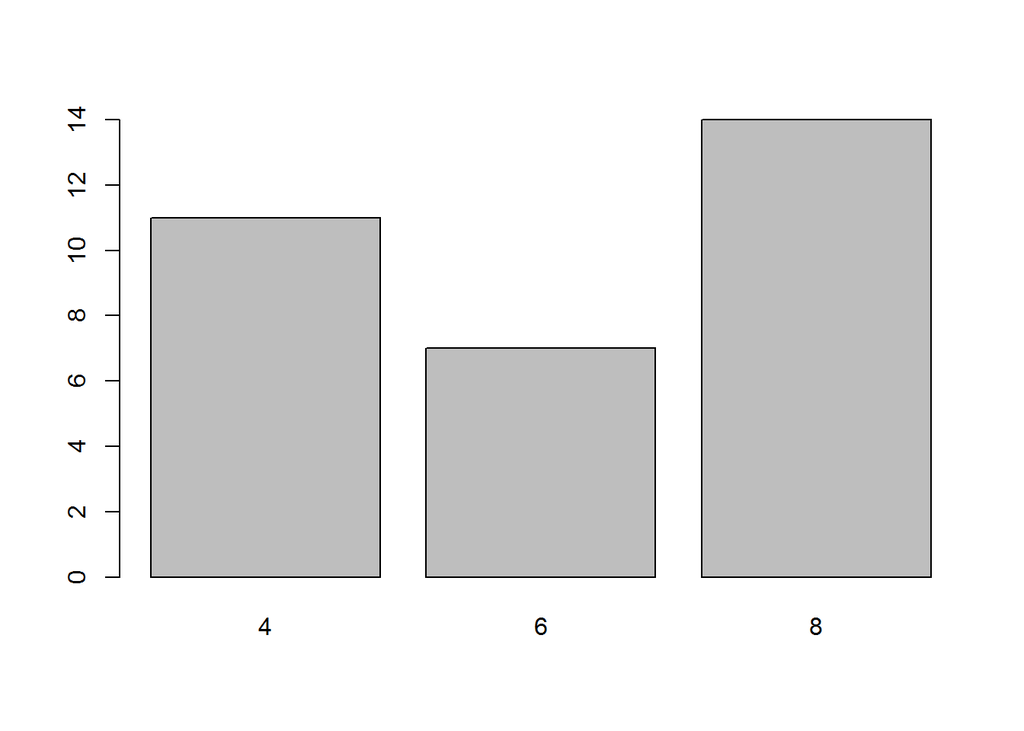

```r
tcyl <- table(cyl)
barplot(tcyl)
```

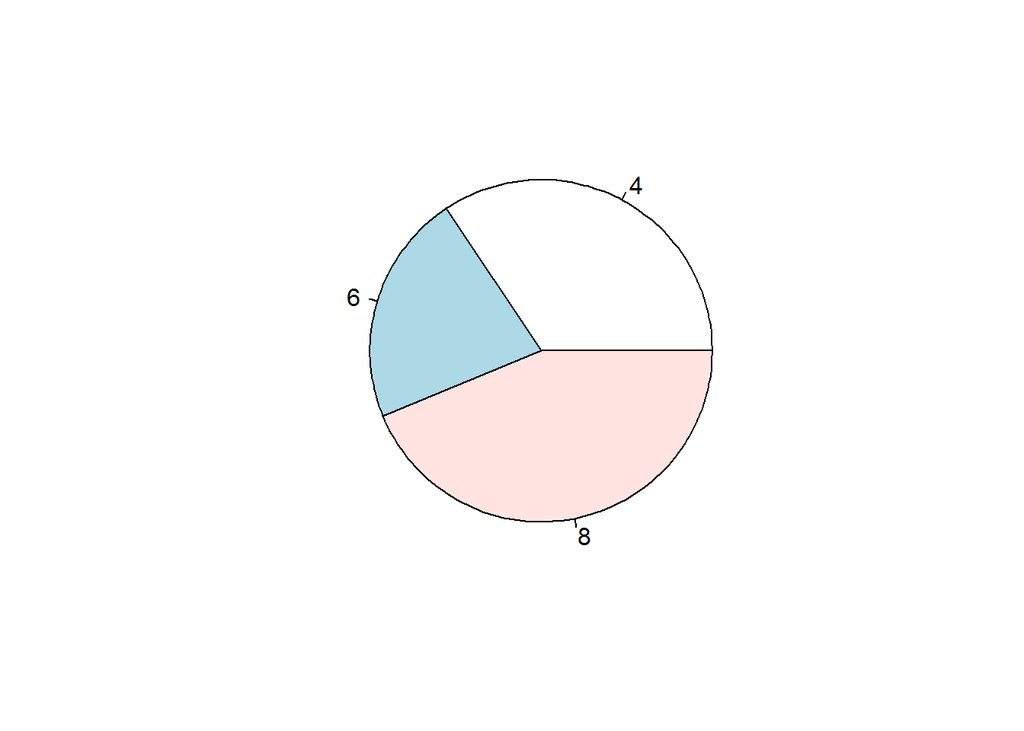

```r
pie(tcyl)
```

```r
tcyl <- 100* table(cyl)/length(cyl)
tcyl
```

```
## cyl
##      4      6      8
## 34.375 21.875 43.750
```

```r
prop.table(tcyl)   # outra forma de obter freq. rel.
```

```
## cyl
##       4       6       8
## 0.34375 0.21875 0.43750
```

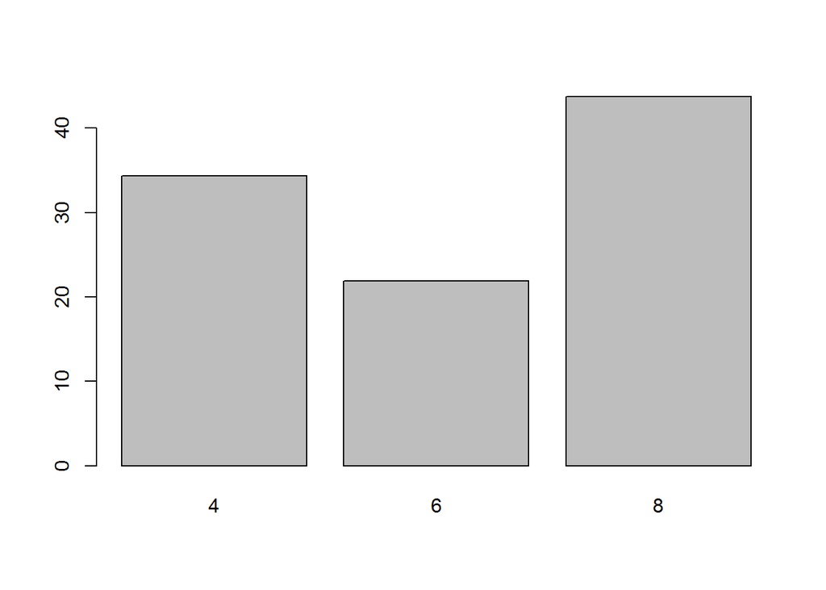

```r
barplot(tcyl)
```

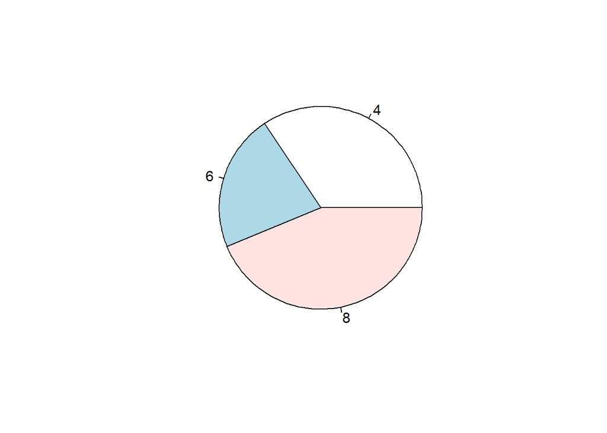

```r
pie(tcyl)
```

Passando agora para uma variável quantitativa contínua vamos ver o comportamento da variável que mede o rendimento dos carros (em mpg - milhas por galão). Primeiro fazemos uma tabela de frequências, depois gráficos (histograma, box-plot e diagrama ramos-e-folhas) e finalmente obtemos algumas medidas que resumem os dados.

```r
table(cut(mpg, br=seq(10,35, 5)))
```

```
##
## (10,15] (15,20] (20,25] (25,30] (30,35]
##       6      12       8       2       4
```

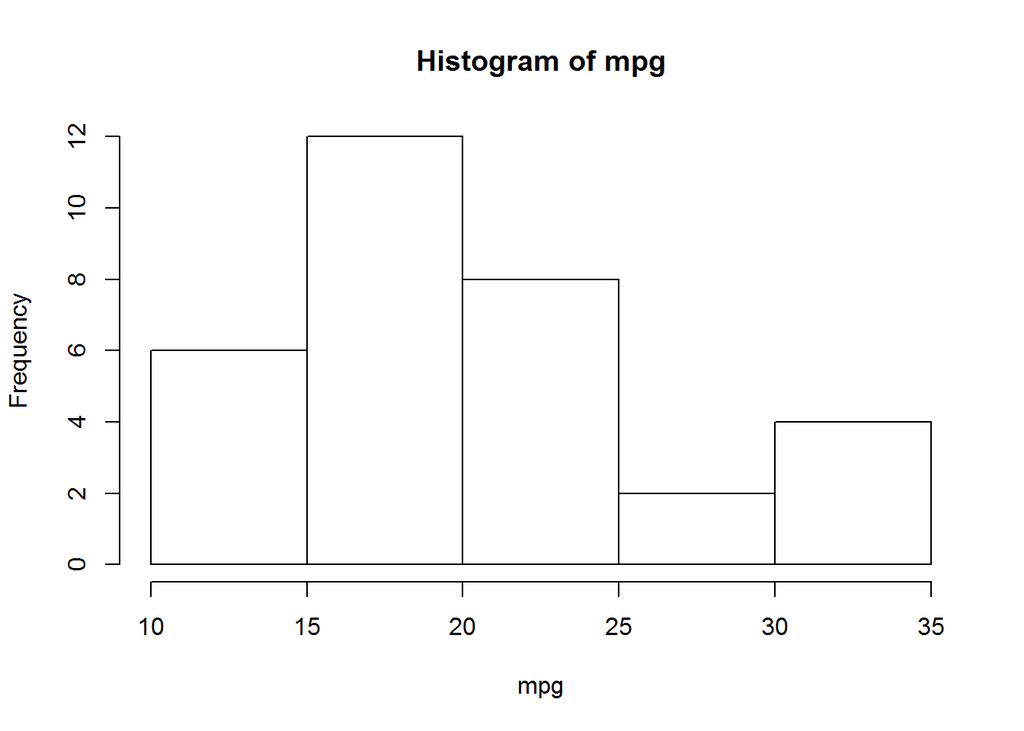

```r
hist(mpg)
```

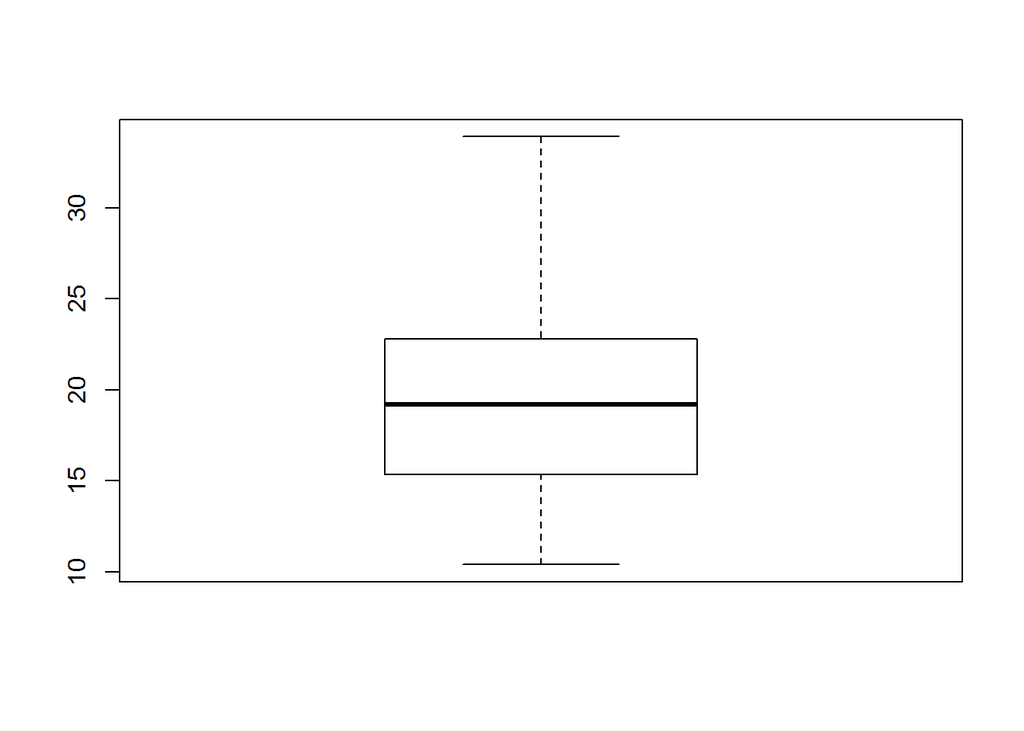

```r
boxplot(mpg)
```

```r
stem(mpg)
```

```
##
##   The decimal point is at the |
##
##   10 | 44
##   12 | 3
##   14 | 3702258
##   16 | 438
##   18 | 17227
##   20 | 00445
##   22 | 88
##   24 | 4
##   26 | 03
##   28 |
##   30 | 44
##   32 | 49
```

```r
summary(mpg)
```

```
##    Min. 1st Qu.  Median    Mean 3rd Qu.    Max.
##   10.40   15.43   19.20   20.09   22.80   33.90
```

## 5.2 Descrição bivariada

Vamos primeiro ver o resumo de duas variáveis categóricas: o tipo de marcha e o número de cilindros. Os comandos abaixo mostram como obter uma tabela com o cruzamento destas variáveis e gráficos.

```r
 table(am, cyl)
```

```
##    cyl
## am   4  6  8
##   0  3  4 12
##   1  8  3  2
```

```r
 prop.table(table(am, cyl))
```

```
##    cyl
## am        4       6       8
##   0 0.09375 0.12500 0.37500
##   1 0.25000 0.09375 0.06250
```

```r
 prop.table(table(am, cyl), margin=1)
```

```
##    cyl
## am          4         6         8
##   0 0.1578947 0.2105263 0.6315789
##   1 0.6153846 0.2307692 0.1538462
```

```r
 prop.table(table(am, cyl), margin=2)
```

```
##    cyl
## am          4         6         8
##   0 0.2727273 0.5714286 0.8571429
##   1 0.7272727 0.4285714 0.1428571
```

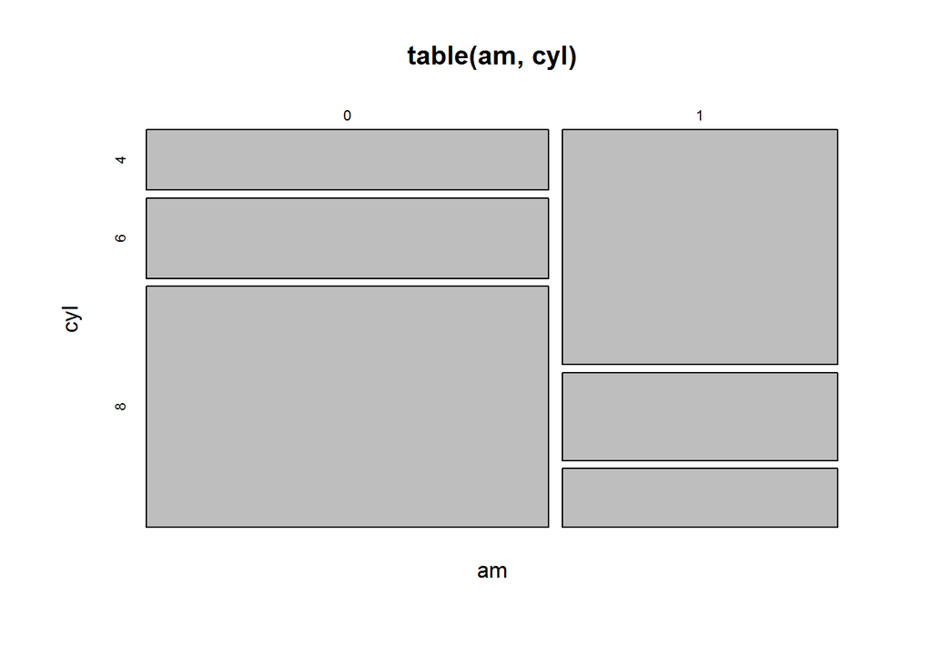

```r
 plot(table(am, cyl))
```

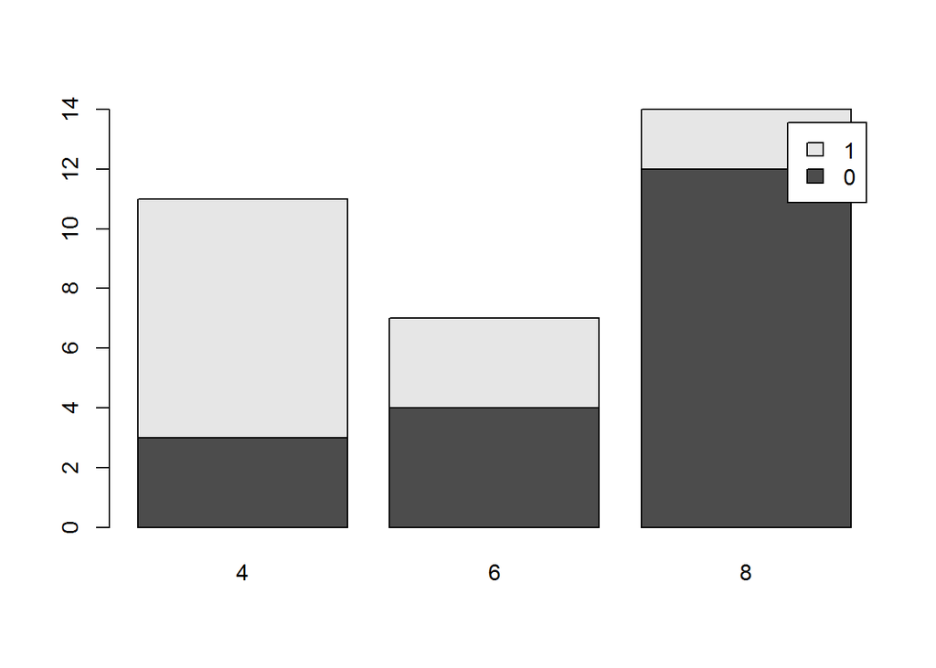

```r
 barplot(table(am, cyl), leg=T)
```

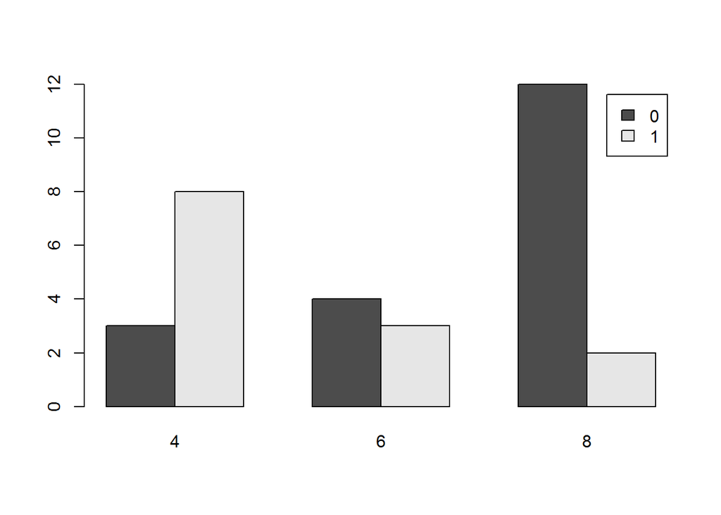

```r
 barplot(table(am, cyl), beside=T, leg=T)
```

Agora vamos relacionar uma categórica (tipo de câmbio) com uma contínua (rendimento). O primeiro comando abaixo mostra como obter medidas resumo do rendimento para cada tipo de câmbio. A seguir são mostrados alguns tipos de gráficos que podem ser obtidos para descrever o comportamento e associação destas variáveis.

```r
 tapply(mpg, am, summary)
```

```
## $`0`
##    Min. 1st Qu.  Median    Mean 3rd Qu.    Max.
##   10.40   14.95   17.30   17.15   19.20   24.40
##
## $`1`
##    Min. 1st Qu.  Median    Mean 3rd Qu.    Max.
##   15.00   21.00   22.80   24.39   30.40   33.90
```

```r
 plot(am, mpg)

 m0 <- mean(mpg[am==0])   # média de rendimento para cambio automático
 m0
```

```
## [1] 17.14737
```

```r
 m1 <- mean(mpg[am==1])   # média de rendimento para cambio manual
 m1
```

```
## [1] 24.39231
```

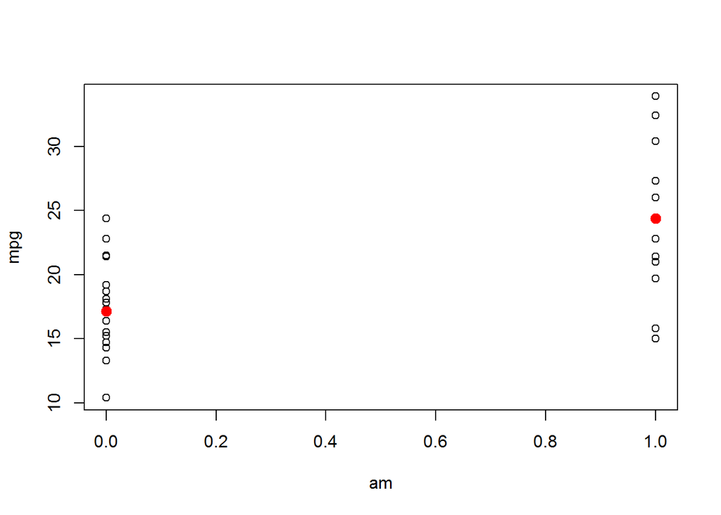

```r
 points(c(0,1), c(m0, m1), cex=2,col=2, pch=20)
```

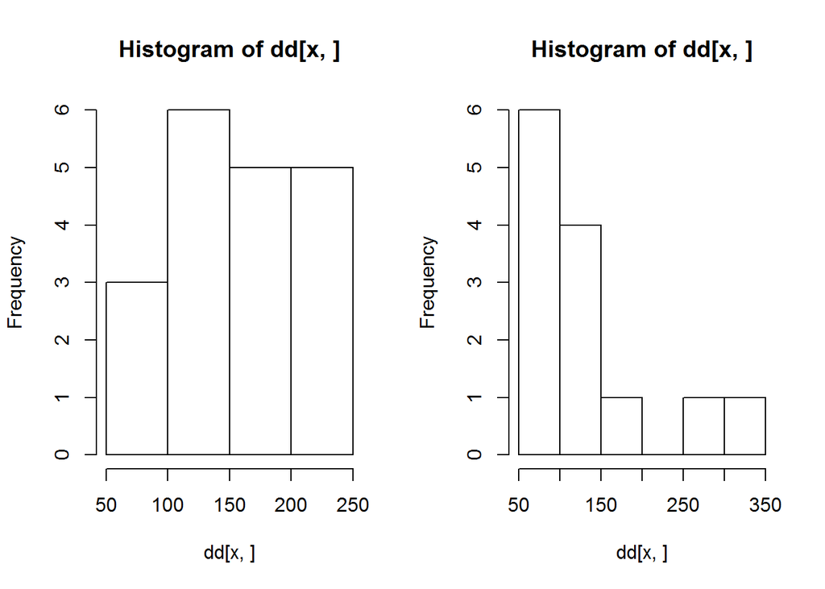

[output not shown]

```r
 par(mfrow=c(1,2))
 by(hp, am, hist)
```

```r
 par(mfrow=c(1,1))
```

Pode-se fazer um teste estatístico (usando o teste $t$) para comparar os redimentos de carros com diferentes tipos de câmbio e/ou com diferentes números de cilindros (usando a análise de variância).

```r
 t.test(mpg[am==0], mpg[am==1])
```

```
##
##  Welch Two Sample t-test
##
## data:  mpg[am == 0] and mpg[am == 1]
## t = -3.7671, df = 18.332, p-value = 0.001374
## alternative hypothesis: true difference in means is not equal to 0
## 95 percent confidence interval:
##  -11.280194  -3.209684
## sample estimates:
## mean of x mean of y
##  17.14737  24.39231
```

```r
 tapply(mpg, cyl, mean)
```

```
##        4        6        8
## 26.66364 19.74286 15.10000
```

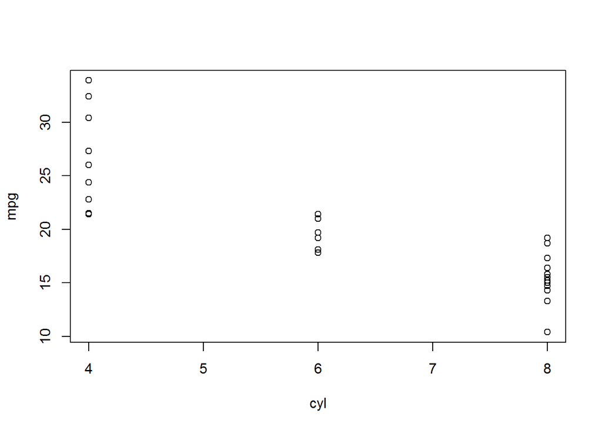

```r
 plot(cyl,mpg)
```

```r
 anova(aov(mpg ~ cyl))
```

```
## Analysis of Variance Table
##
## Response: mpg
##           Df Sum Sq Mean Sq F value    Pr(>F)
## cyl        1 817.71  817.71  79.561 6.113e-10 ***
## Residuals 30 308.33   10.28
## ---
## Signif. codes:  0 '***' 0.001 '**' 0.01 '*' 0.05 '.' 0.1 ' ' 1
```

Passamos agora para a relação entre duas contínuas (peso e rendimento) que pode ser ilustrada como se segue.

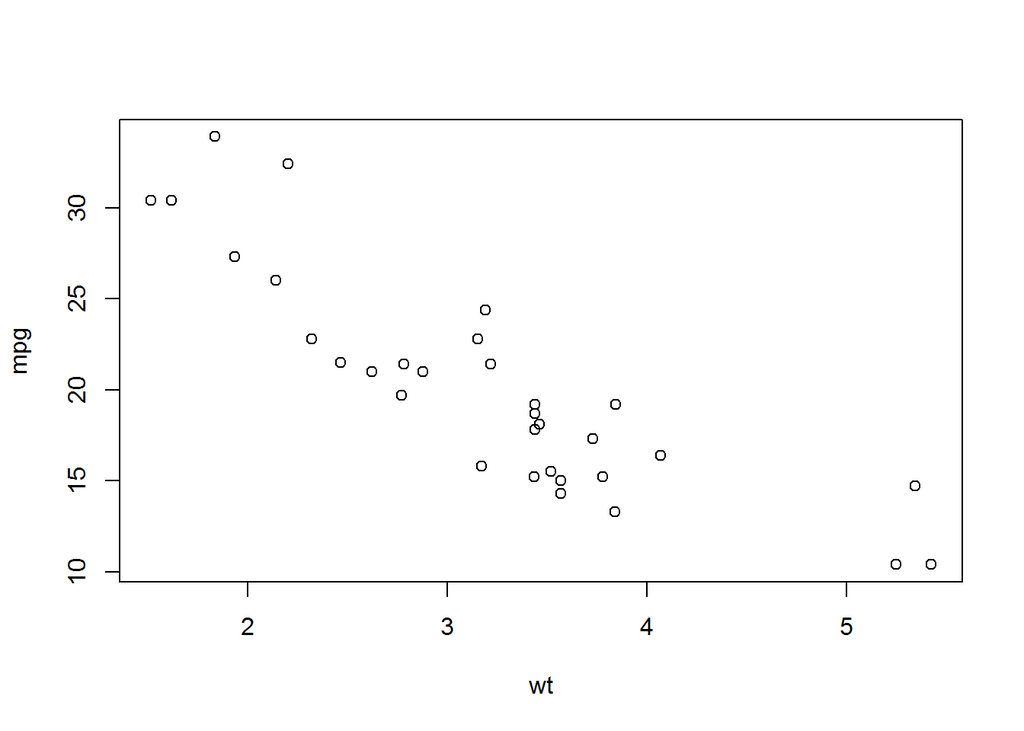

```r
plot(wt, mpg)   # gráfico de rendimento versus peso
```

```r
cor(wt, mpg)    # coeficiente de correlação linear de Pearson
```

```
## [1] -0.8676594
```

Podemos ainda usar recusos gráficos para visualizar três variáveis ao mesmo tempo. Veja os gráficos produzidos com os comandos abaixo.

```r
plot(wt, mpg)   # gráfico de rendimento versus peso
cor(wt, mpg)    # coeficiente de correlação linear de Pearson
```

```
## [1] -0.8676594
```

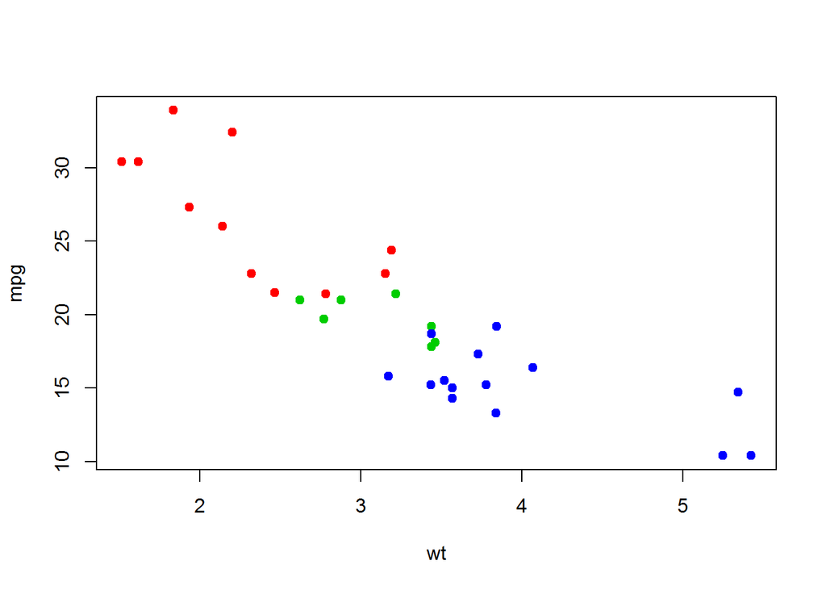

```r
points(wt[cyl==4], mpg[cyl==4], col=2, pch=19)
points(wt[cyl==6], mpg[cyl==6], col=3, pch=19)
points(wt[cyl==8], mpg[cyl==8], col=4, pch=19)
```

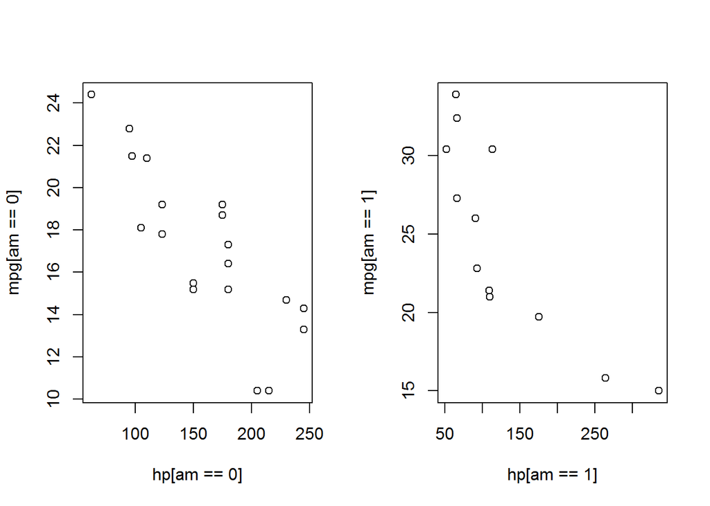

```r
par(mfrow=c(1,2))
plot(hp[am==0], mpg[am == 0])
plot(hp[am==1], mpg[am == 1])
```

```r
par(mfrow=c(1,1))
```

## 5.3 Descrevendo um outro conjunto de dados

Vamos agora utilizar um outro conjunto de dados que já vem disponível com o R - o conjunto airquality.

Estes dados são medidas de: concentração de ozônio (Ozone), radiação solar (Solar.R), velocidade de vento (Wind) e temperatura (Temp) coletados diariamente (Day) por cinco meses (Month).

Primeiramente vamos carregar e visualisar os dados com os comandos:

```r
data(airquality)       # carrega os dados
airquality             # mostra os dados
```

```
##     Ozone Solar.R Wind Temp Month Day
## 1      41     190  7.4   67     5   1
## 2      36     118  8.0   72     5   2
## 3      12     149 12.6   74     5   3
## 4      18     313 11.5   62     5   4
## 5      NA      NA 14.3   56     5   5
## 6      28      NA 14.9   66     5   6
## 7      23     299  8.6   65     5   7
## 8      19      99 13.8   59     5   8
## 9       8      19 20.1   61     5   9
## 10     NA     194  8.6   69     5  10
## 11      7      NA  6.9   74     5  11
## 12     16     256  9.7   69     5  12
## 13     11     290  9.2   66     5  13
## 14     14     274 10.9   68     5  14
```

[output cut: 139 more lines]

```r
#Vamos agora usar alguns comandos para ``conhecer melhor''os dados:

is.data.frame(airquality)    # verifica se é um data-frame
```

```
## [1] TRUE
```

```r
names(airquality)            # nome das colunas (variáveis)
```

```
## [1] "Ozone"   "Solar.R" "Wind"    "Temp"    "Month"   "Day"
```

```r
dim(airquality)              # dimensões do data-frame
```

```
## [1] 153   6
```

```r
help(airquality)             # mostra o ``help''que explica os dados
```

Bem, agora que conhecemos melhor o conjunto airquality, sabemos o número de dados, seu formato, o número de nome das variáveis podemos começar a analisá-los.

Veja por exemplo alguns comandos:

```r
 summary(airquality)             # rápido sumário das variáveis
```

```
##      Ozone           Solar.R           Wind             Temp
##  Min.   :  1.00   Min.   :  7.0   Min.   : 1.700   Min.   :56.00
##  1st Qu.: 18.00   1st Qu.:115.8   1st Qu.: 7.400   1st Qu.:72.00
##  Median : 31.50   Median :205.0   Median : 9.700   Median :79.00
##  Mean   : 42.13   Mean   :185.9   Mean   : 9.958   Mean   :77.88
##  3rd Qu.: 63.25   3rd Qu.:258.8   3rd Qu.:11.500   3rd Qu.:85.00
##  Max.   :168.00   Max.   :334.0   Max.   :20.700   Max.   :97.00
##  NA's   :37       NA's   :7
##      Month            Day
##  Min.   :5.000   Min.   : 1.0
##  1st Qu.:6.000   1st Qu.: 8.0
##  Median :7.000   Median :16.0
##  Mean   :6.993   Mean   :15.8
##  3rd Qu.:8.000   3rd Qu.:23.0
##  Max.   :9.000   Max.   :31.0
##
```

```r
 summary(airquality[,1:4])       # rápido sumário apenas das 4 primeiras variáveis
```

```
##      Ozone           Solar.R           Wind             Temp
##  Min.   :  1.00   Min.   :  7.0   Min.   : 1.700   Min.   :56.00
##  1st Qu.: 18.00   1st Qu.:115.8   1st Qu.: 7.400   1st Qu.:72.00
##  Median : 31.50   Median :205.0   Median : 9.700   Median :79.00
##  Mean   : 42.13   Mean   :185.9   Mean   : 9.958   Mean   :77.88
##  3rd Qu.: 63.25   3rd Qu.:258.8   3rd Qu.:11.500   3rd Qu.:85.00
##  Max.   :168.00   Max.   :334.0   Max.   :20.700   Max.   :97.00
##  NA's   :37       NA's   :7
```

```r
 mean(airquality$Temp)           # média das temperaturas no período
```

```
## [1] 77.88235
```

```r
 mean(airquality$Ozone)          # média do Ozone no período - note a resposta NA
```

```
## [1] NA
```

```r
 airquality$Ozone                # a razão é que existem ``dados perdidos'' na variável Ozone
```

```
##   [1]  41  36  12  18  NA  28  23  19   8  NA   7  16  11  14  18  14  34
##  [18]   6  30  11   1  11   4  32  NA  NA  NA  23  45 115  37  NA  NA  NA
##  [35]  NA  NA  NA  29  NA  71  39  NA  NA  23  NA  NA  21  37  20  12  13
##  [52]  NA  NA  NA  NA  NA  NA  NA  NA  NA  NA 135  49  32  NA  64  40  77
##  [69]  97  97  85  NA  10  27  NA   7  48  35  61  79  63  16  NA  NA  80
##  [86] 108  20  52  82  50  64  59  39   9  16  78  35  66 122  89 110  NA
## [103]  NA  44  28  65  NA  22  59  23  31  44  21   9  NA  45 168  73  NA
## [120]  76 118  84  85  96  78  73  91  47  32  20  23  21  24  44  21  28
## [137]   9  13  46  18  13  24  16  13  23  36   7  14  30  NA  14  18  20
```

```r
 mean(airquality$Ozone, na.rm=T) # média do Ozone no período - retirando
```

```
## [1] 42.12931
```

valores perdidos Note que os útimos tres comandos são trabalhosos de serem digitados pois temos que digitar airquality a cada vez! Mas há um mecanismo no R para facilitar isto: o caminho de procura (``search path’’). Começe digitando e vendo s saída de: search()

O programa vai mostrar o caminho de procura dos objetos. Ou seja, quando voce usa um nome do objeto o R vai procurar este objeto nos caminhos indicado, na ordem apresentada.

Pois bem, podemos ``adicionar’’ um novo local neste caminho de procura e este novo local pode ser o nosso objeto airquality. Digite o seguinte e compare com o anterior:

```r
 attach(airquality)   # anexando o objeto airquality no caminho de procura.
 search()             # mostra o caminho agora com o airquality incluído
```

```
##  [1] ".GlobalEnv"        "airquality"        "mtc"
##  [4] "package:stats"     "package:graphics"  "package:grDevices"
##  [7] "package:utils"     "package:datasets"  "package:methods"
## [10] "Autoloads"         "package:base"
```

```r
 mean(Temp)           # e ... a digitação fica mais fácil e rápida !!!!
```

```
## [1] 77.88235
```

```r
 mean(Ozone, na.rm=T) # pois com o airquality anexado o R acha as variáveis
```

```
## [1] 42.12931
```

NOTA: Para retirar o objeto do caminho de procura basta digitar detach(airquality).

Bem, agora é com voce! Reflita sobre os dados e use seus conhecimentos de estatística para fazer uma análise descritiva interessante destes dados.

Pense em questões relevantes e veja como usar medidas e gráficos para respondê-las. Use os comandos mostrados anteriormente. Por exemplo:

as médias mensais variam entre si? como mostrar a evolução das variáveis no tempo? as variáveis estão relacionadas? etc, etc, etc

```r
setwd("~/R-files/")
milsa <- read.csv("Milsa.csv", header = T, sep = ";")
milsa
```

```
##    civil instrucao filhos salario ano mes regiao
## 1      1         1     NA    4.00  26   3      1
## 2      2         1      1    4.56  32  10      2
## 3      2         1      2    5.25  36   5      2
## 4      1         2     NA    5.73  20  10      3
## 5      1         1     NA    6.26  40   7      3
## 6      2         1      0    6.66  28   0      1
## 7      1         1     NA    6.86  41   0      1
## 8      1         1     NA    7.39  43   4      2
## 9      2         2      1    7.59  34  10      2
## 10     1         2     NA    7.44  23   6      3
## 11     2         2      2    8.12  33   6      1
## 12     1         1     NA    8.46  27  11      2
## 13     1         2     NA    8.74  37   5      3
## 14     2         1      3    8.95  44   2      3
```

[output cut: 22 more lines]

```r
fix(milsa)                    # comando a ser usado para correções, se necessário
```

A planilha digitada como está ainda não está pronta. Precisamos informar para o programa que as variáveis civil, instrucao e regiao, NÃO são numéricas e sim categóricas. No R variáveis categóricas são definidas usando o comando factor(), que vamos usar para redefinir nossas variáveis conforme os comandos a seguir. Primeiro redefinimos a variável civil com os rótulos (labels) solteiro e casado associados aos níveis (levels) 1 e 2. Para variável intrução usamos o argumento adicional ordered = TRUE para indicar que é uma variável ordinal. Na variável regiao codificamos assim: 2=capital, 1=interior, 3=outro. Ao final inspecionamos os dados digitando o nome do objeto.

```r
milsa$civil <- factor(milsa$civil, label=c("solteiro", "casado"), levels=1:2)
milsa$instrucao <- factor(milsa$instrucao, label=c("1oGrau", "2oGrau", "Superior"), lev=1:3, ord=T)
milsa$regiao <- factor(milsa$regiao, label=c("capital", "interior", "outro"), lev=c(2,1,3))
milsa
```

```
##       civil instrucao filhos salario ano mes   regiao
## 1  solteiro    1oGrau     NA    4.00  26   3 interior
## 2    casado    1oGrau      1    4.56  32  10  capital
## 3    casado    1oGrau      2    5.25  36   5  capital
## 4  solteiro    2oGrau     NA    5.73  20  10    outro
## 5  solteiro    1oGrau     NA    6.26  40   7    outro
## 6    casado    1oGrau      0    6.66  28   0 interior
## 7  solteiro    1oGrau     NA    6.86  41   0 interior
## 8  solteiro    1oGrau     NA    7.39  43   4  capital
## 9    casado    2oGrau      1    7.59  34  10  capital
## 10 solteiro    2oGrau     NA    7.44  23   6    outro
## 11   casado    2oGrau      2    8.12  33   6 interior
## 12 solteiro    1oGrau     NA    8.46  27  11  capital
## 13 solteiro    2oGrau     NA    8.74  37   5    outro
## 14   casado    1oGrau      3    8.95  44   2    outro
```

[output cut: 22 more lines]

Agora que os dados estão prontos podemos começar a análise descritiva. Inspecionem os comandos a seguir. Sugerimos que o leitor use o R para reproduzir os resultados mostrados no texto dos capítulos 1 a 3 do livro de Bussab & Morettin relacionados com este exemplo.

Além disto precisamos definir uma variável única idade a partir das variáveis ano e mes que foram digitadas. Para gerar a variável idade (em anos) fazemos:

```r
milsa$idade <- milsa$ano + milsa$mes/12
milsa$idade
```

```
##  [1] 26.25000 32.83333 36.41667 20.83333 40.58333 28.00000 41.00000
##  [8] 43.33333 34.83333 23.50000 33.50000 27.91667 37.41667 44.16667
## [15] 30.41667 38.66667 31.58333 39.58333 25.66667 37.33333 30.75000
## [22] 34.16667 41.00000 26.08333 32.41667 35.00000 46.58333 29.66667
## [29] 40.50000 35.83333 31.41667 36.33333 43.58333 33.58333 48.91667
## [36] 42.16667
```

```r
is.data.frame(milsa) # conferindo se é um data-frame
```

```
## [1] TRUE
```

```r
names(milsa)         # vendo o nome das variáveis
```

```
## [1] "civil"     "instrucao" "filhos"    "salario"   "ano"       "mes"
## [7] "regiao"    "idade"
```

```r
dim(milsa)           # vendo as dimensões do data-frame
```

```
## [1] 36  8
```

```r
attach(milsa)        # anexando ao caminho de procura

##
## Análise Univariada
##

## 1. Variável Qualitativa Nominal
civil
```

```
##  [1] solteiro casado   casado   solteiro solteiro casado   solteiro
##  [8] solteiro casado   solteiro casado   solteiro solteiro casado
## [15] casado   solteiro casado   casado   solteiro solteiro casado
## [22] solteiro solteiro casado   casado   casado   solteiro casado
## [29] casado   casado   solteiro casado   casado   solteiro casado
## [36] casado
## Levels: solteiro casado
```

```r
is.factor(civil)
```

```
## [1] TRUE
```

```r
## 1.1 Tabela:
civil.tb <- table(civil)
civil.tb
```

```
## civil
## solteiro   casado
##       16       20
```

```r
## ou em porcentagem
100 * table(civil)/length(civil)
```

```
## civil
## solteiro   casado
## 44.44444 55.55556
```

```r
## ou então
prop.table(civil.tb)
```

```
## civil
##  solteiro    casado
## 0.4444444 0.5555556
```

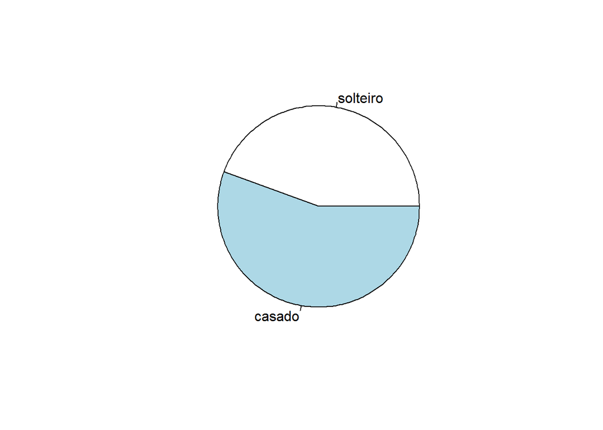

```r
## 1.2 Gráfico
## Para máquinas com baixa resolução gráfica (Sala A - LABEST)
## use o comando da próxima linha (sem os caracteres ##)
## X11(colortype="pseudo.cube")
pie(table(civil))
```

```r
## 1.3 Medidas
## encontrando a moda
civil.mo <- names(civil.tb)[civil.tb == max(civil.tb)]
civil.mo
```

```
## [1] "casado"
```

```r
## 2 Qualitativa Ordinal
instrucao
```

```
##  [1] 1oGrau   1oGrau   1oGrau   2oGrau   1oGrau   1oGrau   1oGrau
##  [8] 1oGrau   2oGrau   2oGrau   2oGrau   1oGrau   2oGrau   1oGrau
## [15] 2oGrau   2oGrau   2oGrau   1oGrau   Superior 2oGrau   2oGrau
## [22] 2oGrau   1oGrau   Superior 2oGrau   2oGrau   1oGrau   2oGrau
## [29] 2oGrau   2oGrau   Superior 2oGrau   Superior Superior 2oGrau
## [36] Superior
## Levels: 1oGrau < 2oGrau < Superior
```

```r
is.factor(instrucao)
```

```
## [1] TRUE
```

```r
## 2.1 Tabela:
instrucao.tb <- table(instrucao)
instrucao.tb
```

```
## instrucao
##   1oGrau   2oGrau Superior
##       12       18        6
```

```r
prop.table(instrucao.tb)
```

```
## instrucao
##    1oGrau    2oGrau  Superior
## 0.3333333 0.5000000 0.1666667
```

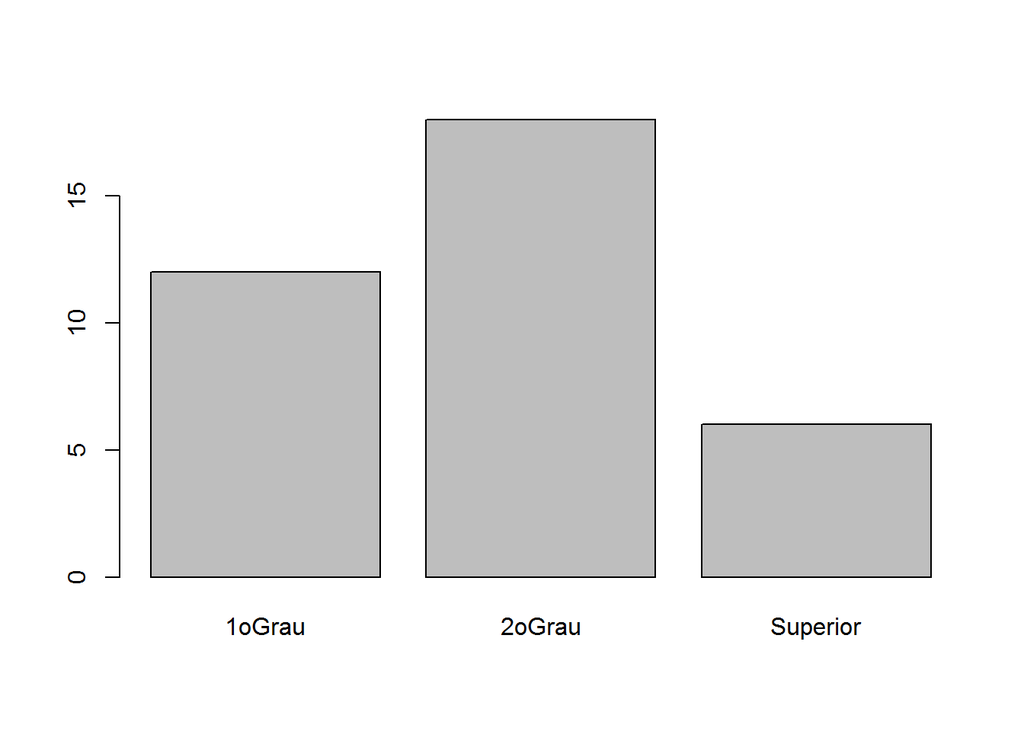

```r
## 2.2 Gráfico:
barplot(instrucao.tb)
```

```r
## 2.3 Medidas
instrucao.mo <- names(instrucao.tb)[instrucao.tb == max(instrucao.tb)]
instrucao.mo
```

```
## [1] "2oGrau"
```

```r
median(as.numeric(instrucao)) # só calcula mediana de variáveis numéricas
```

```
## [1] 2
```

```r
levels(milsa$instrucao)[median(as.numeric(milsa$instrucao))]
```

```
## [1] "2oGrau"
```

```r
## 3 Quantitativa discreta
filhos
```

```
##  [1] NA  1  2 NA NA  0 NA NA  1 NA  2 NA NA  3  0 NA  1  2 NA NA  1 NA NA
## [24]  0  2  2 NA  0  5  2 NA  1  3 NA  2  3
```

```r
## 3.1 Tabela:
filhos.tb <- table(filhos)
filhos.tb
```

```
## filhos
## 0 1 2 3 5
## 4 5 7 3 1
```

```r
filhos.tb/sum(filhos.tb) # frequências relativas
```

```
## filhos
##    0    1    2    3    5
## 0.20 0.25 0.35 0.15 0.05
```

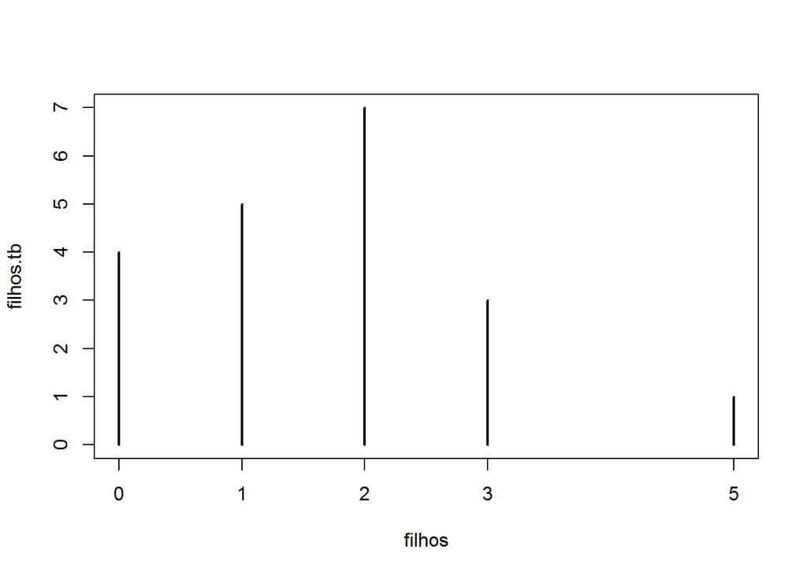

```r
## 3.2 Gráfico:
plot(filhos.tb)            # gráfico das frequências absolutas
```

```r
filhos.fac <- cumsum(filhos.tb)
filhos.fac                 # frequências acumuladas
```

```
##  0  1  2  3  5
##  4  9 16 19 20
```

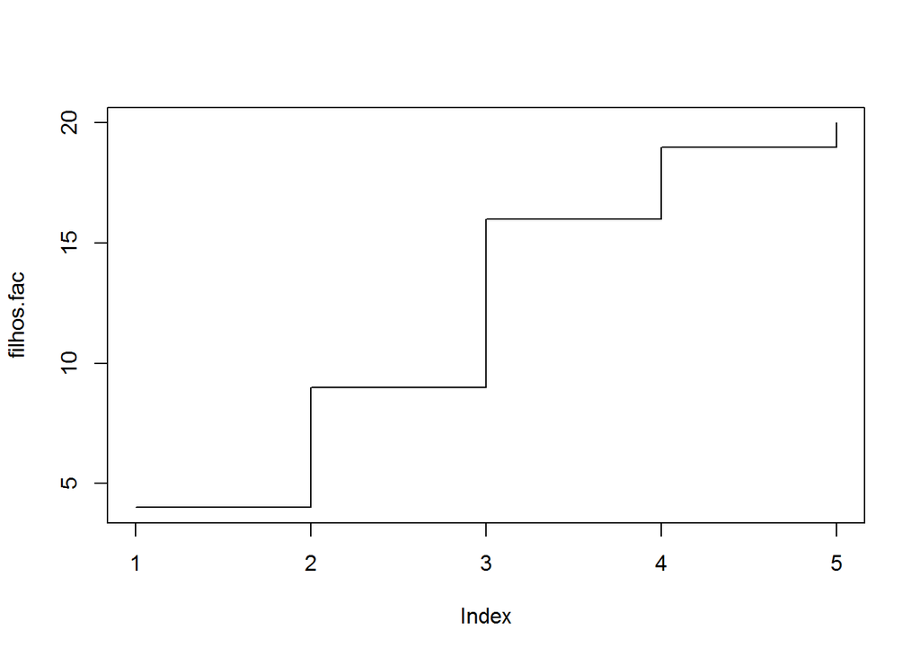

```r
plot(filhos.fac, type="s") # gráfico das frequências acumuladas
```

```r
## 3.3 Medidas
## De posição
filhos.mo <- names(filhos.tb)[filhos.tb == max(filhos.tb)]
filhos.mo                  # moda
```

```
## [1] "2"
```

```r
filhos.md <- median(filhos, na.rm=T)
filhos.md                  # mediana
```

```
## [1] 2
```

```r
filhos.me <- mean(filhos, na.rm=T)
filhos.me                  # média
```

```
## [1] 1.65
```

```r
## Medida de dispersão
range(filhos, na.rm=T)
```

```
## [1] 0 5
```

```r
diff(range(filhos, na.rm=T)) # amplitude
```

```
## [1] 5
```

```r
filhos.dp <- sd(filhos, na.rm=T)   # desvio padrão
filhos.dp
```

```
## [1] 1.268028
```

```r
var(filhos, na.rm=T)       # variância
```

```
## [1] 1.607895
```

```r
100 * filhos.dp/filhos.me  # coeficiente de variação
```

```
## [1] 76.85018
```

```r
filhos.qt <- quantile(filhos, na.rm=T)
filhos.qt[4] - filhos.qt[2] # amplitude interquartílica
```

```
## 75%
##   1
```

```r
summary(filhos)            # várias medidas
```

```
##    Min. 1st Qu.  Median    Mean 3rd Qu.    Max.    NA's
##    0.00    1.00    2.00    1.65    2.00    5.00      16
```

```r
## 4. Quantitativa Contínua
salario
```

```
##  [1]  4.00  4.56  5.25  5.73  6.26  6.66  6.86  7.39  7.59  7.44  8.12
## [12]  8.46  8.74  8.95  9.13  9.35  9.77  9.80 10.53 10.76 11.06 11.59
## [23] 12.00 12.79 13.23 13.60 13.85 14.69 14.71 15.99 16.22 16.61 17.26
## [34] 18.75 19.40 23.30
```

```r
## 4.1 Tabela
range(salario)          # máximo e mínimo
```

```
## [1]  4.0 23.3
```

```r
nclass.Sturges(salario) # número de classes pelo critério de Sturges
```

```
## [1] 7
```

```r
args(cut)
```

```
## function (x, ...)
## NULL
```

```r
args(cut.default)
```

```
## function (x, breaks, labels = NULL, include.lowest = FALSE, right = TRUE,
##     dig.lab = 3L, ordered_result = FALSE, ...)
## NULL
```

```r
table(cut(salario, seq(3.5,23.5,l=8)))
```

```
##
##  (3.5,6.36] (6.36,9.21] (9.21,12.1] (12.1,14.9] (14.9,17.8] (17.8,20.6]
##           5          10           8           6           4           2
## (20.6,23.5]
##           1
```

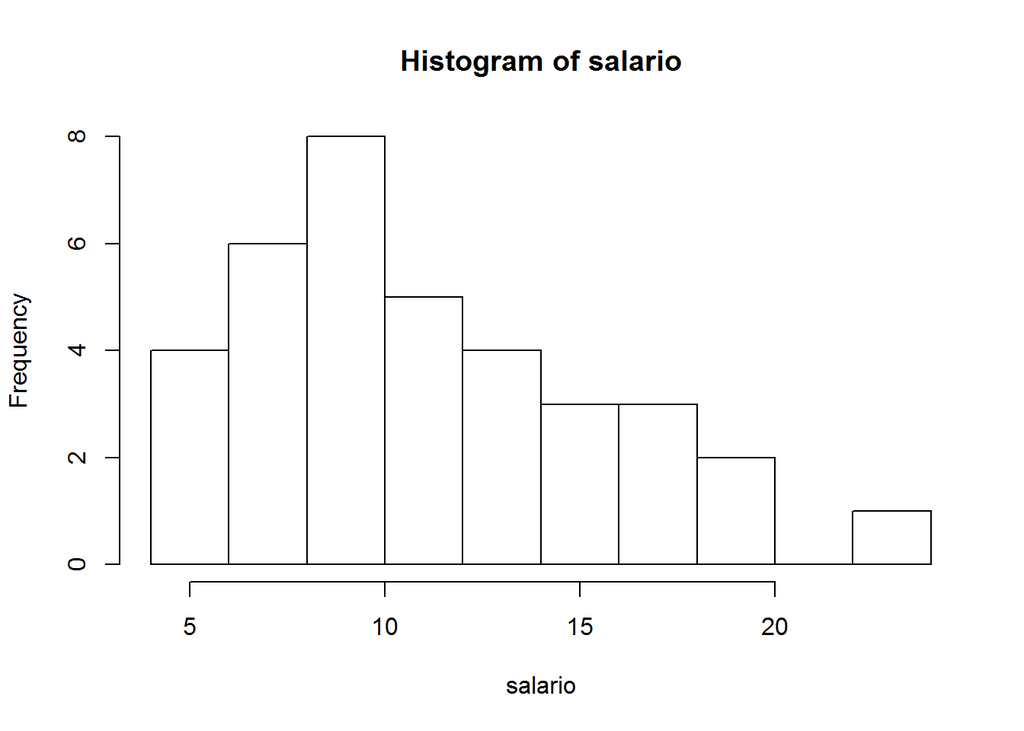

```r
## 4.2 Gráfico
hist(salario)
```

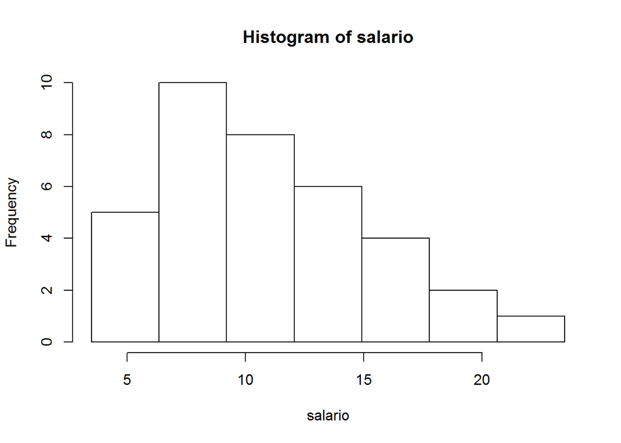

```r
hist(salario, br=seq(3.5,23.5,l=8))
```

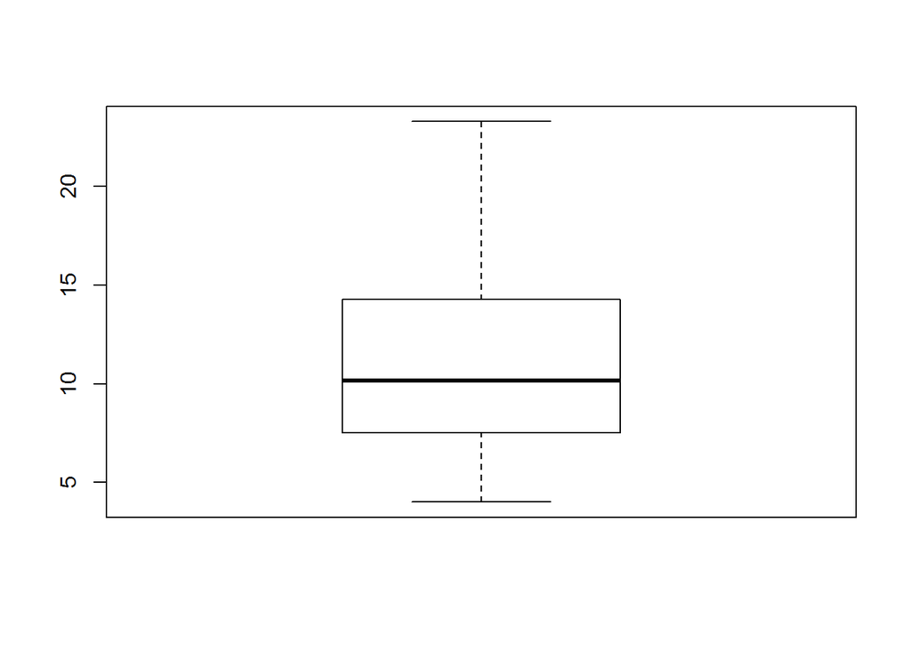

```r
boxplot(salario)
```

```r
stem(salario)
```

```
##
##   The decimal point is at the |
##
##    4 | 0637
##    6 | 379446
##    8 | 15791388
##   10 | 5816
##   12 | 08268
##   14 | 77
##   16 | 0263
##   18 | 84
##   20 |
##   22 | 3
```

```r
## 4.3 Medidas
## De posição
salario.md <- median(salario, na.rm=T)
salario.md                # mediana
```

```
## [1] 10.165
```

```r
salario.me <- mean(salario, na.rm=T)
salario.me                # média
```

```
## [1] 11.12222
```

```r
## Medida de dispersão
range(salario, na.rm=T)
```

```
## [1]  4.0 23.3
```

```r
diff(range(salario, na.rm=T)) # amplitude
```

```
## [1] 19.3
```

```r
salario.dp <- sd(salario, na.rm=T)   # desvio padrão
salario.dp
```

```
## [1] 4.587458
```

```r
var(salario, na.rm=T)     # variância
```

```
## [1] 21.04477
```

```r
100 * salario.dp/salario.me  # coeficiente de variação
```

```
## [1] 41.24587
```

```r
salario.qt <- quantile(salario, na.rm=T)
salario.qt[4] - salario.qt[2] # amplitude interquartílica
```

```
##    75%
## 6.5075
```

```r
summary(salario)          # várias medidas
```

```
##    Min. 1st Qu.  Median    Mean 3rd Qu.    Max.
##   4.000   7.553  10.165  11.122  14.060  23.300
```

```r
##
## Análise Bivariada
##
## 1. Qualitativa vs Qualitativa
## Ex. estado civil e grau de instrução

## 1.1 Tabela
civ.gi.tb <- table(civil, instrucao) # frequências absolutas
civ.gi.tb
```

```
##           instrucao
## civil      1oGrau 2oGrau Superior
##   solteiro      7      6        3
##   casado        5     12        3
```

```r
civ.gi.tb/as.vector(table(civil))    # frequências por linha
```

```
##           instrucao
## civil      1oGrau 2oGrau Superior
##   solteiro 0.4375 0.3750   0.1875
##   casado   0.2500 0.6000   0.1500
```

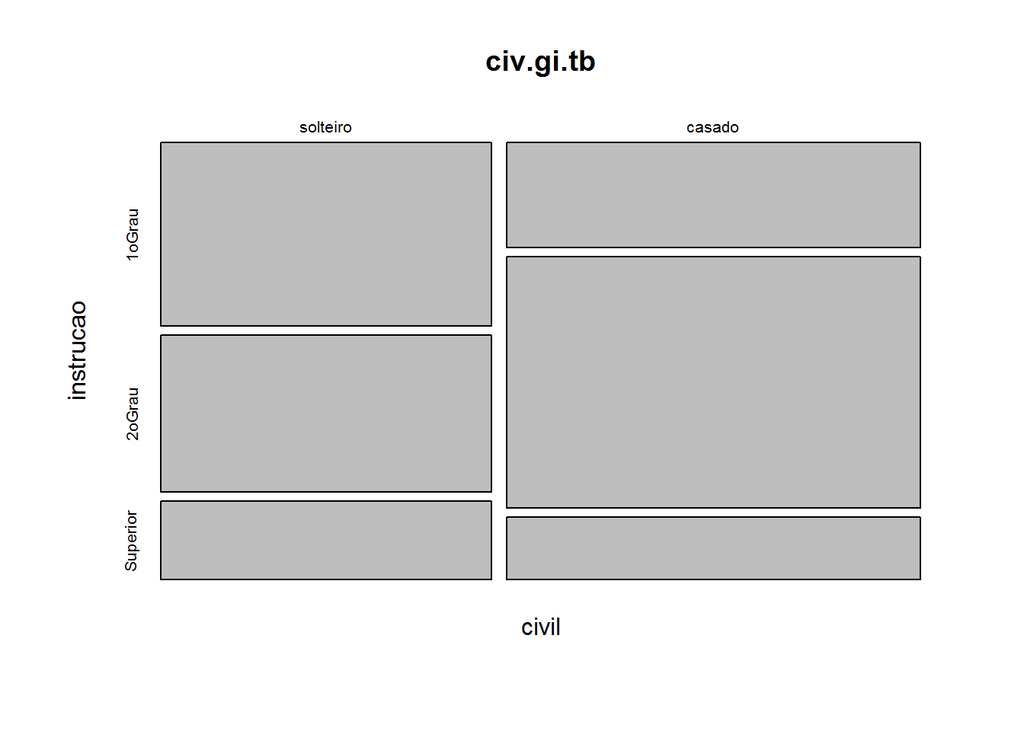

```r
## 1.2 Gráfico
plot(civ.gi.tb)
```

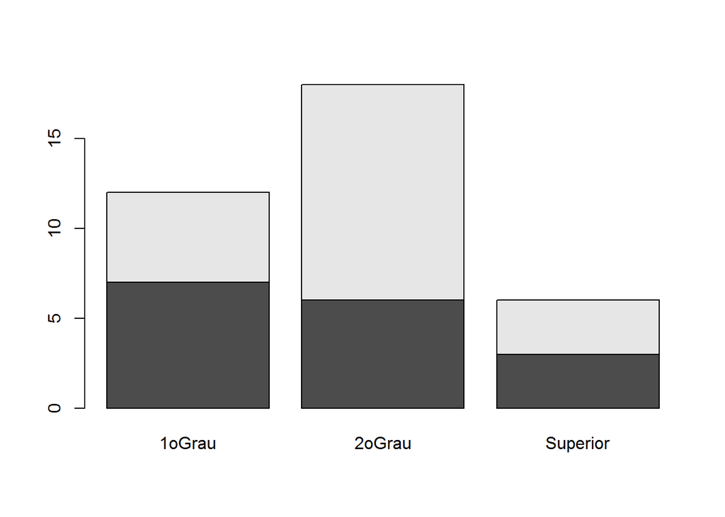

```r
barplot(civ.gi.tb)
```

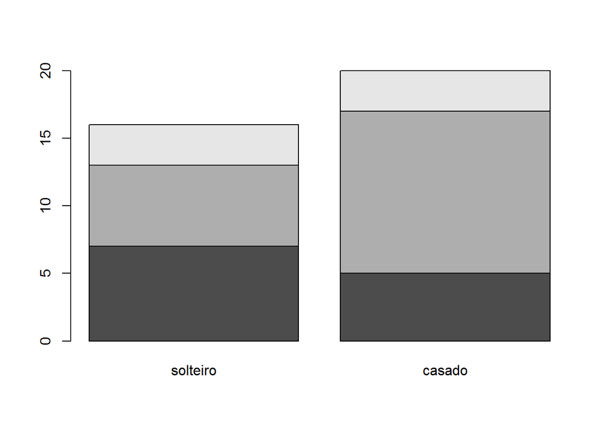

```r
barplot(t(civ.gi.tb))
```

```r
## 1.3. Medida de associação
summary(civ.gi.tb)   # resumo incluindo o teste Chi-quadrado
```

```
## Number of cases in table: 36
## Number of factors: 2
## Test for independence of all factors:
##  Chisq = 1.9125, df = 2, p-value = 0.3843
##  Chi-squared approximation may be incorrect
```

```r
## criando uma nova variável para agrupar 2o Grau e Superior
instrucao1 <- ifelse(instrucao == 1, 1, 2)
table(instrucao)
```

```
## instrucao
##   1oGrau   2oGrau Superior
##       12       18        6
```

```r
table(instrucao1)
```

```
## instrucao1
##  2
## 36
```

```r
table(civil, instrucao1)
```

```
##           instrucao1
## civil       2
##   solteiro 16
##   casado   20
```

```r
summary(table(civil, instrucao1))
```

```
## Number of cases in table: 36
## Number of factors: 2
## Test for independence of all factors:
##  Chisq = 0, df = 0, p-value = 1
```

```r
## 2. Qualitativa vs Quantitativa
## Ex. grau de instrução vs salário

## 2.1 Tabela
quantile(salario)
```

```
##      0%     25%     50%     75%    100%
##  4.0000  7.5525 10.1650 14.0600 23.3000
```

```r
ins.sal.tb <- table(instrucao, cut(salario, quantile(salario)))
ins.sal.tb
```

```
##
## instrucao  (4,7.55] (7.55,10.2] (10.2,14.1] (14.1,23.3]
##   1oGrau          6           3           2           0
##   2oGrau          2           6           5           5
##   Superior        0           0           2           4
```

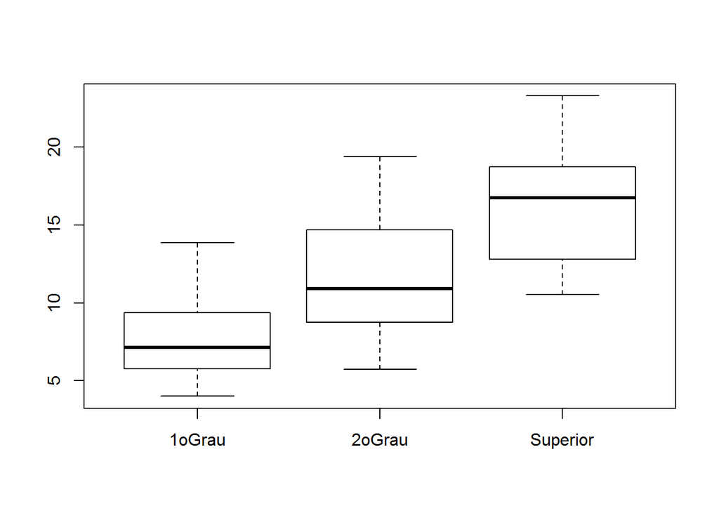

```r
## 2.2 Gráfico
plot(instrucao, salario)
```

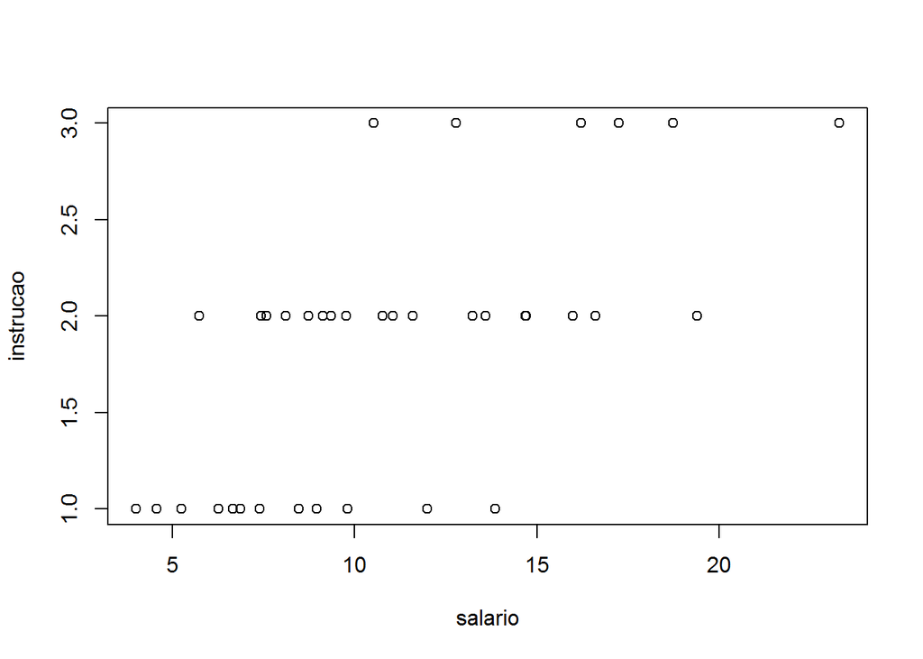

```r
plot(salario, instrucao)
```

```r
## 2.3 Medidas
## calculando as média para cada grau de instrução
tapply(salario, instrucao, mean)
```

```
##    1oGrau    2oGrau  Superior
##  7.836667 11.528333 16.475000
```

```r
## e as variâncias
tapply(salario, instrucao, var)
```

```
##    1oGrau    2oGrau  Superior
##  8.740679 13.802297 20.271950
```

```r
## e ainda os mínimo, máximo e quartis
tapply(salario, instrucao, quantile)
```

```
## $`1oGrau`
##      0%     25%     50%     75%    100%
##  4.0000  6.0075  7.1250  9.1625 13.8500
##
## $`2oGrau`
##      0%     25%     50%     75%    100%
##  5.7300  8.8375 10.9100 14.4175 19.4000
##
## $Superior
##      0%     25%     50%     75%    100%
## 10.5300 13.6475 16.7400 18.3775 23.3000
```

```r
## 3. Quantitativa vs Quantitativa
## Ex. salário e idade

## 3.1 Tabela
table(cut(idade, quantile(idade)), cut(salario, quantile(salario)))
```

```
##
##               (4,7.55] (7.55,10.2] (10.2,14.1] (14.1,23.3]
##   (20.8,30.7]        2           2           2           1
##   (30.7,34.9]        1           3           3           2
##   (34.9,40.5]        1           3           2           3
##   (40.5,48.9]        3           1           2           3
```

```r
table(cut(idade, quantile(idade, seq(0,1,len=4))), cut(salario, quantile(salario, seq(0,1,len=4))))
```

```
##
##               (4,8.65] (8.65,12.9] (12.9,23.3]
##   (20.8,32.1]        3           5           2
##   (32.1,37.8]        4           3           5
##   (37.8,48.9]        3           4           5
```

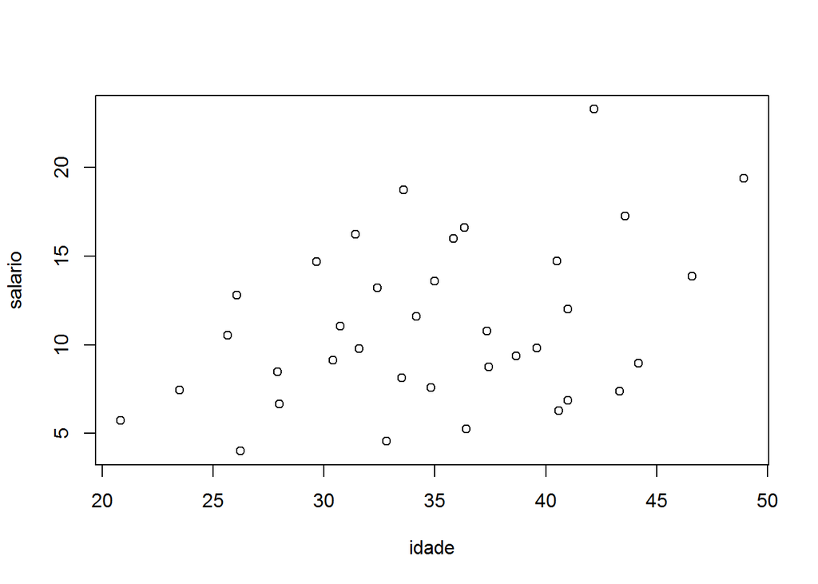

```r
## 3.2 Gráfico
plot(idade, salario)
```

```r
## 3.3 Medidas
cor(idade, salario)
```

```
## [1] 0.3651397
```

```r
detach(milsa)             # desanexando do caminha de procura
```